# Table of Contents

# Nelson-Siegel :

$ y(t) = \beta_0 + \beta_1 \left( \frac{1 - e^{-t/\tau_1}}{t/\tau_1} \right) + \beta_2 \left( \frac{1 - e^{-t/\tau_1}}{t/\tau_1} - e^{-t/\tau_1} \right) $

Where:

- $ y(t) $ is the yield at time $(t $)
- $( \beta_0, \beta_1, \beta_2 $) are parameters that determine the level, slope, and curvature of the yield curve, respectively.
- $( \tau_1 $) is a parameter that determines the speed at which the curve transitions from the short-term rate to the long-term rate.

```python
# nelson_siegel function
def nelson_siegel(t, beta0, beta1, beta2, tau1):
    term1 = beta0
    term2 = beta1 * ((1 - np.exp(-t/tau1)) / (t/tau1))
    term3 = beta2 * ((1 - np.exp(-t/tau1)) / (t/tau1) - np.exp(-t/tau1))
    return term1 + term2 + term3
```

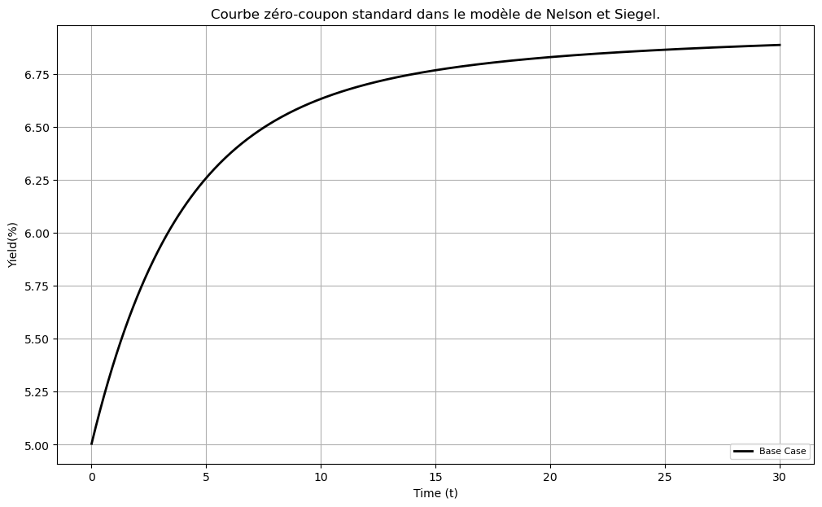

```python
# Define the base-case parameters
beta0 = 0.07
beta1 = -0.02
beta2 = 0.01
tau1 = 3.33

# Define the time array
t = np.linspace(0.01, 30, 500)  # start from 0.01 to avoid division by zero

# Calculate the base-case yield curve
base_curve = nelson_siegel(t, beta0, beta1, beta2, tau1)

# Plot
plt.figure(figsize=(12, 7))
plt.plot(t, base_curve*100, label="Base Case", color="black", linewidth=2)
plt.title("Courbe zéro-coupon standard dans le modèle de Nelson et Siegel.")
plt.xlabel("Time (t)")
plt.ylabel("Yield(%)")
plt.legend(loc='lower right', fontsize="8")
plt.grid(True)
plt.show()
```

## Slope Factor Impact

The slope factor in the Nelson-Siegel model is represented by $( \beta_1 $). To understand the impact of the slope factor on the yield curve shape, we vary $( \beta_1 $) over a range of values.

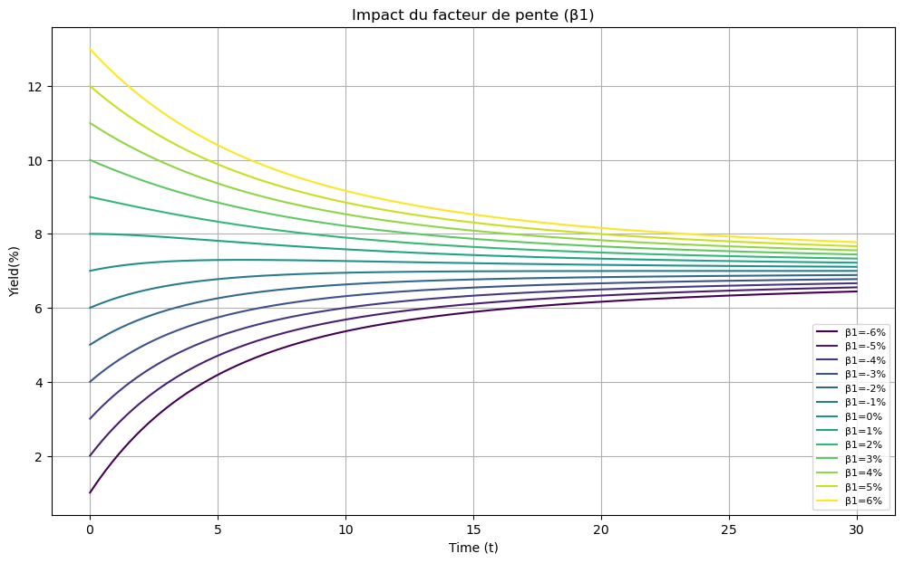

```python
# Define a range of values for beta1 to see its impact on the curve
beta1_values = [-0.06, -0.05, -0.04, -0.03, -0.02, -0.01, 0, 0.01, 0.02, 0.03, 0.04, 0.05, 0.06]
colors = plt.cm.viridis(np.linspace(0, 1, len(beta1_values)))

# Plot of the curves for each value of beta1
plt.figure(figsize=(12, 7))

for val, color in zip(beta1_values, colors):
    curve = nelson_siegel(t, beta0, val, beta2, tau1)
    plt.plot(t, curve*100, label=f"β1={val*100:.0f}%", color=color)

# Plot
plt.title("Impact du facteur de pente (β1)")
plt.xlabel("Time (t)")
plt.ylabel("Yield(%)")
plt.legend(loc='lower right', fontsize="8")
plt.grid(True)
plt.show()
```

## Curvature Factor Impact

The curvature factor in the Nelson-Siegel model is represented by $( \beta_2 $). To see the impact of the curvature factor on the yield curve shape, we vary $( \beta_2 $) over a range of values.

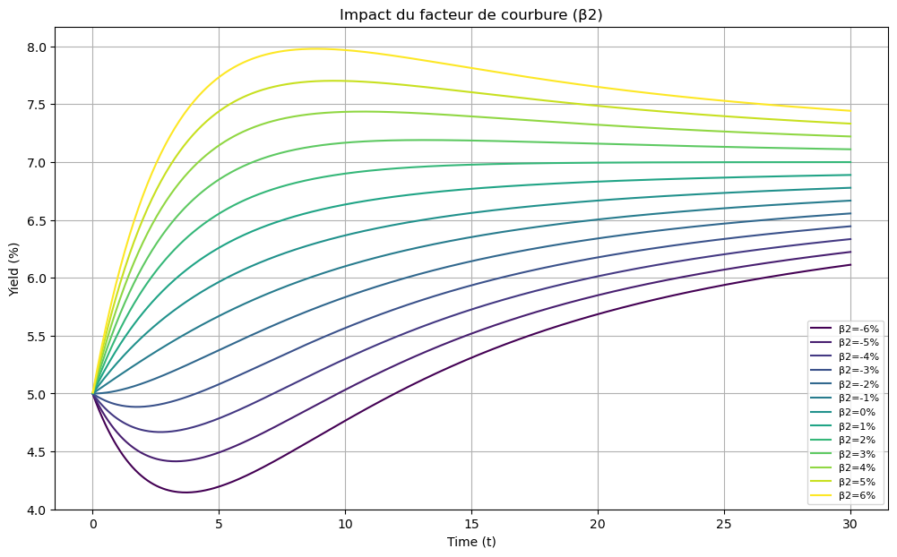

```python
# Define a range of values for beta2 to see its impact on the curve
beta2_values =  [-0.06, -0.05, -0.04, -0.03, -0.02, -0.01, 0, 0.01, 0.02, 0.03, 0.04, 0.05, 0.06]
colors = plt.cm.viridis(np.linspace(0, 1, len(beta2_values)))

# Plot the curves for each value of beta2 with yield axis starting at 4%
plt.figure(figsize=(12, 7))

for val, color in zip(beta2_values, colors):
    curve = nelson_siegel(t, beta0, beta1, val, tau1)
    plt.plot(t, curve*100, label=f"β2={val*100:.0f}%", color=color)  # Multiply by 100 for %

# Plot
plt.title("Impact du facteur de courbure (β2)")
plt.xlabel("Time (t)")
plt.ylabel("Yield (%)")
plt.ylim(4, None)  # Start y-axis at 4%
plt.legend(loc='lower right', fontsize="8")
plt.grid(True)
plt.show()
```

# Extended Nelson-Siegel (Svensson)

$$ Y(t) = \beta_0 + \beta_1 \left( \frac{1 - e^{-\lambda t}}{\lambda t} \right) + \beta_2 \left( \frac{1 - e^{-\lambda t}}{\lambda t} - e^{-\lambda t} \right) + \beta_3 \left( \frac{1 - e^{-\lambda_2 t}}{\lambda_2 t} - e^{-\lambda_2 t} \right) $$

Parameters:

- $ Y(t) $: Yield at time $(t $)
- $ t $: Time to maturity
- $ \beta_0 $: Long-term rate
- $ \beta_1 $: Short-term rate
- $ \beta_2 $: Curvature parameter
- $ \beta_3 $: Additional curvature parameter
- $ \lambda $: Decay parameter for the short-term and curvature components
- $ \lambda_2 $: Decay parameter for the additional curvature component

```python
def nelson_siegel_svensson(t, beta0, beta1, beta2, beta3, tau1, tau2):
    """
    Computes the yield for maturity t using the Nelson-Siegel-Svensson model.
    """
    term1 = beta0
    term2 = beta1 * (1 - np.exp(-t/tau1)) / (t/tau1)
    term3 = beta2 * ((1 - np.exp(-t/tau1)) / (t/tau1) - np.exp(-t/tau1))
    term4 = beta3 * ((1 - np.exp(-t/tau2)) / (t/tau2) - np.exp(-t/tau2))
    return term1 + term2 + term3 + term4
```

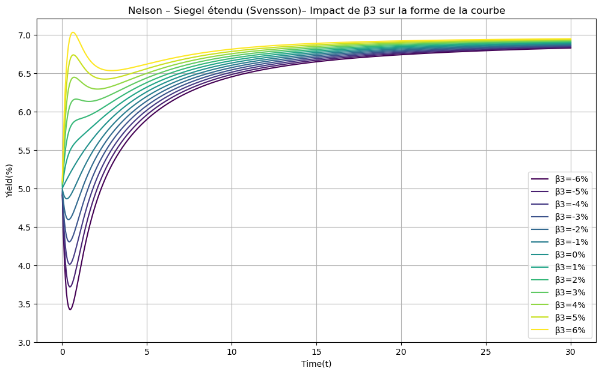

```python
# Define the base-case parameters and time array
beta0 = 0.07
beta1 = -0.02
beta2 = 0.01
beta3_base = -0.01
tau1 = 3.33
tau2 = 0.3
t = np.linspace(0.01, 30, 500)  # start from 0.01 to avoid division by zero

# Define a range of values for beta3 to see its impact on the curve
beta3_values = np.linspace(-0.06, 0.06, 13)
colors = plt.cm.viridis(np.linspace(0, 1, len(beta3_values)))

# Plot the curves for each value of beta3
plt.figure(figsize=(12, 7))

for val, color in zip(beta3_values, colors):
    curve = nelson_siegel_svensson(t, beta0, beta1, beta2, val, tau1, tau2)
    plt.plot(t, curve*100, label=f"β3={val*100:.0f}%", color=color)  # Multiply by 100 for %


plt.title("Nelson – Siegel étendu (Svensson)– Impact de β3 sur la forme de la courbe")
plt.xlabel("Time(t)")
plt.ylabel("Yield(%)")
plt.ylim(3, None)  # Start y-axis at 4%
plt.legend()
plt.grid(True)
plt.show()
```

## IPyWidget

```python
# Create an interactive plot with high precision ipywidgets
def interactive_plot_high_precision():
    t_values = np.linspace(0.01, 30, 400)  # time values from 0.01 to 30

    beta0_slider = widgets.FloatSlider(value=0, min=-1.0, max=1.0, step=0.00000001, description='beta0 (level)', readout_format='.8f')
    beta1_slider = widgets.FloatSlider(value=0, min=-1.0, max=1.0, step=0.00000001, description='beta1 (slope)', readout_format='.8f')
    beta2_slider = widgets.FloatSlider(value=0, min=-1.0, max=1.0, step=0.00000001, description='beta2 (shape)', readout_format='.8f')
    beta3_slider = widgets.FloatSlider(value=0, min=-1.0, max=1.0, step=0.00000001, description='beta3 (shape)', readout_format='.8f')
    lambda1_slider = widgets.FloatSlider(value=0, min=-1.0, max=1.0, step=0.00000001, description='lambda1 (decay)', readout_format='.8f')
    lambda2_slider = widgets.FloatSlider(value=0, min=-1.0, max=1.0, step=0.00000001, description='lambda2 (decay)', readout_format='.8f')

    ui = widgets.VBox([beta0_slider, beta1_slider, beta2_slider, beta3_slider, lambda1_slider, lambda2_slider])

    def plot_curve(beta0, beta1, beta2, beta3, lambda1, lambda2):
        y_values = nelson_siegel_svensson(t_values, beta0, beta1, beta2, beta3, lambda1, lambda2)
        plt.figure(figsize=(10, 6))
        plt.plot(t_values, y_values, label="Nelson-Siegel-Svensson Curve")
        plt.title("Nelson-Siegel-Svensson Yield Curve")
        plt.xlabel("Time")
        plt.ylabel("Yield")
        plt.legend()
        plt.grid(True)
        plt.show()

    out = widgets.interactive_output(plot_curve, {'beta0': beta0_slider, 'beta1': beta1_slider, 'beta2': beta2_slider, 'beta3': beta3_slider, 'lambda1': lambda1_slider, 'lambda2': lambda2_slider})

    display(ui, out)

interactive_plot_high_precision()
```

```
VBox(children=(FloatSlider(value=0.0, description='beta0 (level)', max=1.0, min=-1.0, readout_format='.8f', st…
```

```
Output()
```

```python
# Define the objective function to minimize (mean squared error)
def objective_function(beta, t, y):
    beta0, beta1, beta2,beta3, tau1, tau2 = beta
    y_pred = nelson_siegel_svensson(t, beta0, beta1, beta2,beta3, tau1, tau2)
    return np.sum((y - y_pred)**2)
```

```python
def Interpolates_NSS(df):
    """
    Interpolates rates between maturity dates using the Nelson-Siegel-Svensson model.

    Parameters:
    - df (DataFrame): A DataFrame containing 'TradeDate', 'MaturityDate', and 'Rate' columns.

    Returns:
    - DataFrame: A DataFrame containing interpolated rates for the maturity dates (business days) using the NSS model.
    """
    # Convert necessary columns to datetime format
    df['MaturityDate'] = pd.to_datetime(df['MaturityDate'])
    df['TradeDate'] = pd.to_datetime(df['TradeDate'])

    # Compute maturity in days
    df['TimetoMaturity'] = (df['MaturityDate'] - df['TradeDate']).dt.days

    # Initial guesses for NSS model parameters
    beta0 = df['Rate'].tail(2).mean()
    beta1 = df['Rate'].min() - df['Rate'].max()
    beta2 = df['Rate'].min()
    beta3 = df['Rate'].min()
    tau1 =  df['TimetoMaturity'].min() - df['TimetoMaturity'].max()
    tau2 =  df['TimetoMaturity'].head(2).mean()



    # Minimize the objective function to estimate parameters
    result = minimize(objective_function, [beta0, beta1, beta2, beta3, tau1, tau2],
                      args=(df['TimetoMaturity'], df['Rate']), method='trust-constr')

    params = result.x

    # Determine the range of business days for interpolation
    date_range = pd.bdate_range(start=df['MaturityDate'].min(), end=df['MaturityDate'].max())
    interpolated_days = (date_range - df['TradeDate'].iloc[0]).days

    # Interpolate rates using the fitted NSS model parameters
    nss_interpolated_rates = nelson_siegel_svensson(interpolated_days, *params)

    # Create a DataFrame for the interpolated rates
    interpolated_data = pd.DataFrame({
        'MaturityDate': date_range,
        'InterpolatedRate': nss_interpolated_rates
    })

    return interpolated_data
```

### Nelson-Siegel-Svensson : €STR

```python
ESTR_NSS = Interpolates_NSS(ESTR_df)
ESTR_NSS
```

|  | MaturityDate | InterpolatedRate |
| --- | --- | --- |
| 0 | 2023-08-24 | 3.657582 |
| 1 | 2023-08-25 | 3.651865 |
| 2 | 2023-08-28 | 3.640901 |
| 3 | 2023-08-29 | 3.638843 |
| 4 | 2023-08-30 | 3.637396 |
| ... | ... | ... |
| 258 | 2024-08-20 | 3.727269 |
| 259 | 2024-08-21 | 3.726268 |
| 260 | 2024-08-22 | 3.725258 |
| 261 | 2024-08-23 | 3.724238 |
| 262 | 2024-08-26 | 3.721121 |

263 rows × 2 columns

### Nelson-Siegel-Svensson : SOFR

```python
SOFR_NSS = Interpolates_NSS(SOFR_df)
SOFR_NSS
```

|  | MaturityDate | InterpolatedRate |
| --- | --- | --- |
| 0 | 2023-08-24 | 5.301652 |
| 1 | 2023-08-25 | 5.300422 |
| 2 | 2023-08-28 | 5.297786 |
| 3 | 2023-08-29 | 5.297220 |
| 4 | 2023-08-30 | 5.296793 |
| ... | ... | ... |
| 258 | 2024-08-20 | 5.373320 |
| 259 | 2024-08-21 | 5.372155 |
| 260 | 2024-08-22 | 5.370980 |
| 261 | 2024-08-23 | 5.369793 |
| 262 | 2024-08-26 | 5.366172 |

263 rows × 2 columns

### Nelson-Siegel-Svensson : SONIA

```python
SONIA_NSS = Interpolates_NSS(SONIA_df)
SONIA_NSS
```

|  | MaturityDate | InterpolatedRate |
| --- | --- | --- |
| 0 | 2023-08-24 | 5.196187 |
| 1 | 2023-08-25 | 5.183689 |
| 2 | 2023-08-28 | 5.159422 |
| 3 | 2023-08-29 | 5.154829 |
| 4 | 2023-08-30 | 5.151607 |
| ... | ... | ... |
| 257 | 2024-08-19 | 5.804588 |
| 258 | 2024-08-20 | 5.804474 |
| 259 | 2024-08-21 | 5.804346 |
| 260 | 2024-08-22 | 5.804204 |
| 261 | 2024-08-23 | 5.804049 |

262 rows × 2 columns

### Nelson-Siegel-Svensson : TONAR

```python
TONAR_NSS = Interpolates_NSS(TONAR_df)
TONAR_NSS
```

|  | MaturityDate | InterpolatedRate |
| --- | --- | --- |
| 0 | 2023-09-01 | -0.076779 |
| 1 | 2023-09-04 | -0.077090 |
| 2 | 2023-09-05 | -0.077182 |
| 3 | 2023-09-06 | -0.077268 |
| 4 | 2023-09-07 | -0.077349 |
| ... | ... | ... |
| 187 | 2024-05-21 | -0.027698 |
| 188 | 2024-05-22 | -0.027435 |
| 189 | 2024-05-23 | -0.027172 |
| 190 | 2024-05-24 | -0.026910 |
| 191 | 2024-05-27 | -0.026122 |

192 rows × 2 columns

### Nelson-Siegel-Svensson Plot

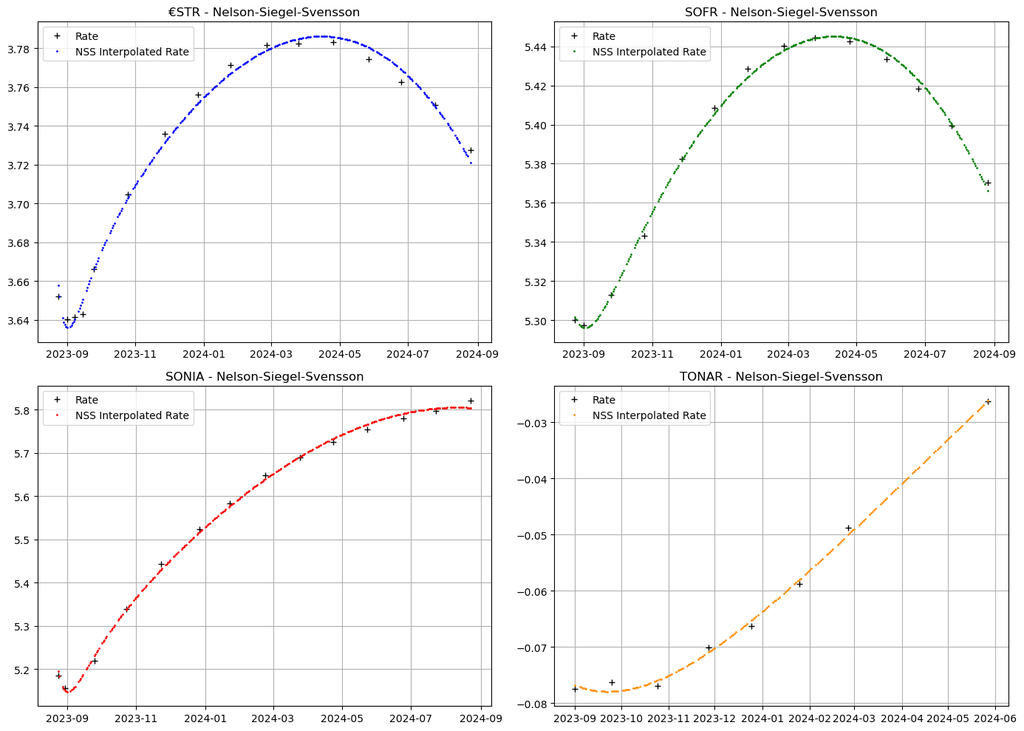

```python
# Plotting the Hermite basis functions
plt.figure(figsize=(14, 10))

# €STR
plt.subplot(2, 2, 1)
plt.plot(ESTR_df['MaturityDate'], ESTR_df['Rate'], '+', label='Rate', color='black',  markersize=6)
plt.plot(ESTR_NSS['MaturityDate'], ESTR_NSS['InterpolatedRate'], 'o', label='NSS Interpolated Rate', color='blue', markersize=1)
plt.title("€STR - Nelson-Siegel-Svensson")
plt.grid(True)
plt.legend()

# SOFR
plt.subplot(2, 2, 2)
plt.plot(SOFR_df['MaturityDate'], SOFR_df['Rate'], '+', label='Rate', color='black',  markersize=6)
plt.plot(SOFR_NSS['MaturityDate'], SOFR_NSS['InterpolatedRate'], 'o', label='NSS Interpolated Rate', color='green', markersize=1)
plt.title("SOFR - Nelson-Siegel-Svensson")
plt.grid(True)
plt.legend()

# SONIA
plt.subplot(2, 2, 3)
plt.plot(SONIA_df['MaturityDate'], SONIA_df['Rate'], '+', label='Rate', color='black',  markersize=6)
plt.plot(SONIA_NSS['MaturityDate'], SONIA_NSS['InterpolatedRate'], 'o', label='NSS Interpolated Rate', color='red', markersize=1)
plt.title("SONIA - Nelson-Siegel-Svensson")
plt.grid(True)
plt.legend()

# TONAR
plt.subplot(2, 2, 4)
plt.plot(TONAR_df['MaturityDate'], TONAR_df['Rate'], '+', label='Rate', color='black',  markersize=6)
plt.plot(TONAR_NSS['MaturityDate'], TONAR_NSS['InterpolatedRate'], 'o', label='NSS Interpolated Rate', color='darkorange', markersize=1)
plt.title("TONAR - Nelson-Siegel-Svensson")
plt.grid(True)
plt.legend()

plt.tight_layout()
plt.show()
```

# Monotone Cubic Hermite

The Monotone Cubic Hermite Interpolation formula can be expressed as follows:

$$ P(t) = (2t^3 - 3t^2 + 1)P_0 + (t^3 - 2t^2 + t) m_0 + (-2t^3 + 3t^2)P_1 + (t^3 - t^2) m_1 $$

Parameters:

- $ P(t) $: Interpolated value at $( t $)
- $ P_0 $: Function value at the starting point
- $ P_1 $: Function value at the ending point
- $ m_0 $: Tangent at the starting point
- $ m_1 $: Tangent at the ending point
- $ t $: Parameter varying between 0 and 1

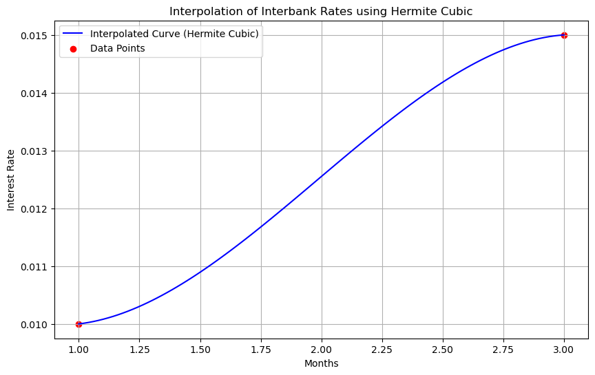

```python
# Given data points and derivatives
x_data = [1, 3]  # months
y_data = [0.01, 0.015]  # interest rates for 1 month and 3 months respectively
m_data = [0.0005, 0.0003]  # rate changes (derivatives) at the given points

# Hermite cubic interpolation function
def hermite_cubic(x, x0, x1, y0, y1, m0, m1):
    t = (x - x0) / (x1 - x0)
    h00 = 2*t**3 - 3*t**2 + 1
    h10 = t**3 - 2*t**2 + t
    h01 = -2*t**3 + 3*t**2
    h11 = t**3 - t**2
    return h00*y0 + h10*m0*(x1-x0) + h01*y1 + h11*m1*(x1-x0)

# Generating x values for interpolation
x_vals = np.linspace(1, 3, 100)
y_vals = [hermite_cubic(x, x_data[0], x_data[1], y_data[0], y_data[1], m_data[0], m_data[1]) for x in x_vals]

# Plotting the data
plt.figure(figsize=(10,6))
plt.plot(x_vals, y_vals, label="Interpolated Curve (Hermite Cubic)", color="blue")
plt.scatter(x_data, y_data, color="red", marker="o", label="Data Points")
plt.title("Interpolation of Interbank Rates using Hermite Cubic")
plt.xlabel("Months")
plt.ylabel("Interest Rate")
plt.legend()
plt.grid(True)
plt.show()
```

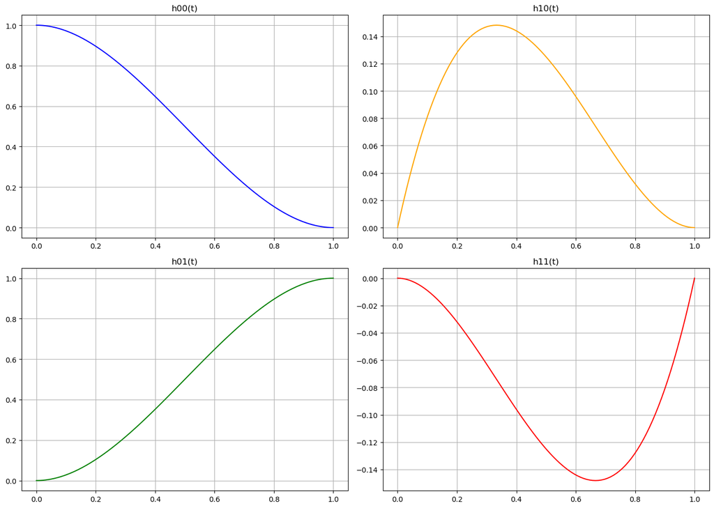

```python
# Defining individual Hermite basis functions for visualization
def h00(t):
    return 2*t**3 - 3*t**2 + 1

def h10(t):
    return t**3 - 2*t**2 + t

def h01(t):
    return -2*t**3 + 3*t**2

def h11(t):
    return t**3 - t**2

# Generating values
t_vals = np.linspace(0, 1, 100)
h00_vals = [h00(t) for t in t_vals]
h10_vals = [h10(t) for t in t_vals]
h01_vals = [h01(t) for t in t_vals]
h11_vals = [h11(t) for t in t_vals]

# Plotting the Hermite basis functions
plt.figure(figsize=(14, 10))

# h00(t)
plt.subplot(2, 2, 1)
plt.plot(t_vals, h00_vals, label="h00(t)", color="blue")
plt.title("h00(t)")
plt.grid(True)

# h10(t)
plt.subplot(2, 2, 2)
plt.plot(t_vals, h10_vals, label="h10(t)", color="orange")
plt.title("h10(t)")
plt.grid(True)

# h01(t)
plt.subplot(2, 2, 3)
plt.plot(t_vals, h01_vals, label="h01(t)", color="green")
plt.title("h01(t)")
plt.grid(True)

# h11(t)
plt.subplot(2, 2, 4)
plt.plot(t_vals, h11_vals, label="h11(t)", color="red")
plt.title("h11(t)")
plt.grid(True)

plt.tight_layout()
plt.show()
```

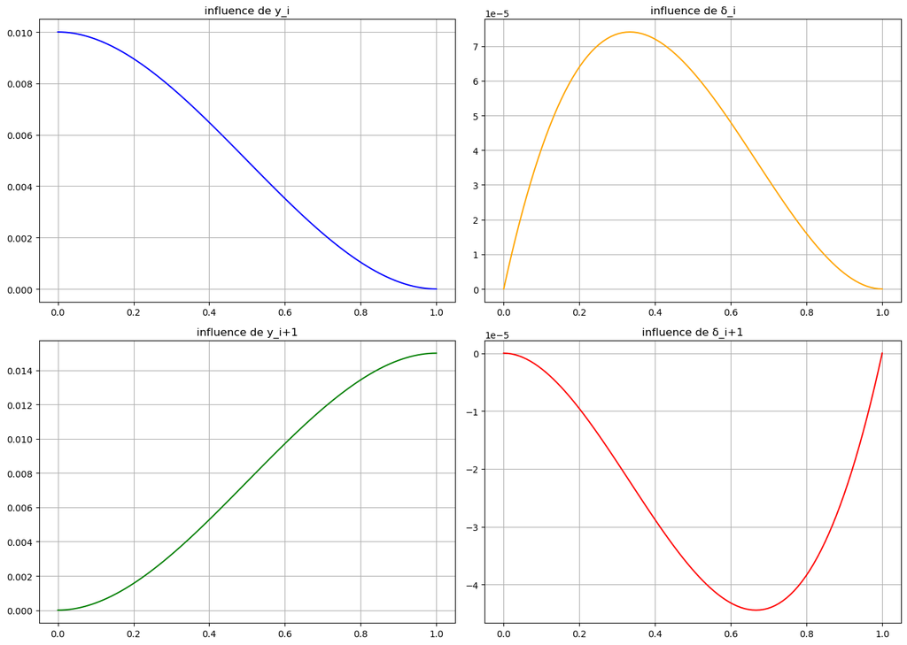

```python
# Calculating the contribution of each term to the final curve
y0_term = [h00(t) * y_data[0] for t in t_vals]
m0_term = [h10(t) * m_data[0] for t in t_vals]
y1_term = [h01(t) * y_data[1] for t in t_vals]
m1_term = [h11(t) * m_data[1] for t in t_vals]

# Plotting the influence of each term
plt.figure(figsize=(14, 10))

# y0 term
plt.subplot(2, 2, 1)
plt.plot(t_vals, y0_term, label="y0 * h00(t)", color="blue")
plt.title("influence de y_i")
plt.grid(True)

# m0 term
plt.subplot(2, 2, 2)
plt.plot(t_vals, m0_term, label="m0 * h10(t)", color="orange")
plt.title("influence de δ_i")
plt.grid(True)

# y1 term
plt.subplot(2, 2, 3)
plt.plot(t_vals, y1_term, label="y1 * h01(t)", color="green")
plt.title("influence de y_i+1")
plt.grid(True)

# m1 term
plt.subplot(2, 2, 4)
plt.plot(t_vals, m1_term, label="m1 * h11(t)", color="red")
plt.title("influence de δ_i+1")
plt.grid(True)

plt.tight_layout()
plt.show()
```

## Interpolation Monotone Cubic Hermite

```python
def Monotone(df):
    """
    Interpolates rates between maturity dates using PchipInterpolator.

    Parameters:
    - df (DataFrame): A DataFrame containing 'MaturityDate' and 'Rate' columns.

    Returns:
    - DataFrame: A DataFrame containing interpolated rates for the maturity dates (business days).
    """
    # Convert MaturityDate to datetime format
    df['MaturityDate'] = pd.to_datetime(df['MaturityDate'])

    # Identify the range of business days between the earliest and latest maturity dates
    date_range = pd.bdate_range(start=df['MaturityDate'].min(), end=df['MaturityDate'].max())

    # Convert maturity dates to ordinal numbers for interpolation
    x_values = df['MaturityDate'].apply(lambda x: x.toordinal()).values
    y_values = df['Rate'].values

    # Interpolate using PchipInterpolator
    interpolator = PchipInterpolator(x_values, y_values)
    interpolated_rates = interpolator(date_range.to_series().apply(lambda x: x.toordinal()).values)

    # Create a DataFrame for the interpolated rates
    interpolated_data = pd.DataFrame({
        'MaturityDate': date_range,
        'InterpolatedRate': interpolated_rates
    })

    return interpolated_data
```

## Monotone cubic Hermite : €STR

```python
ESTR_M = Monotone(ESTR_df)
ESTR_M
```

|  | MaturityDate | InterpolatedRate |
| --- | --- | --- |
| 0 | 2023-08-24 | 3.652000 |
| 1 | 2023-08-25 | 3.649691 |
| 2 | 2023-08-28 | 3.643747 |
| 3 | 2023-08-29 | 3.642279 |
| 4 | 2023-08-30 | 3.641161 |
| ... | ... | ... |
| 258 | 2024-08-20 | 3.732598 |
| 259 | 2024-08-21 | 3.731738 |
| 260 | 2024-08-22 | 3.730868 |
| 261 | 2024-08-23 | 3.729989 |
| 262 | 2024-08-26 | 3.727300 |

263 rows × 2 columns

## Monotone cubic Hermite : SOFR

```python
SOFR_M = Monotone(SOFR_df)
SOFR_M
```

|  | MaturityDate | InterpolatedRate |
| --- | --- | --- |
| 0 | 2023-08-24 | 5.300000 |
| 1 | 2023-08-25 | 5.299487 |
| 2 | 2023-08-28 | 5.298265 |
| 3 | 2023-08-29 | 5.297983 |
| 4 | 2023-08-30 | 5.297774 |
| ... | ... | ... |
| 258 | 2024-08-20 | 5.376544 |
| 259 | 2024-08-21 | 5.375540 |
| 260 | 2024-08-22 | 5.374527 |
| 261 | 2024-08-23 | 5.373507 |
| 262 | 2024-08-26 | 5.370400 |

263 rows × 2 columns

## Monotone cubic Hermite : SONIA

```python
SONIA_M = Monotone(SONIA_df)
SONIA_M
```

|  | MaturityDate | InterpolatedRate |
| --- | --- | --- |
| 0 | 2023-08-24 | 5.185900 |
| 1 | 2023-08-25 | 5.179475 |
| 2 | 2023-08-28 | 5.161751 |
| 3 | 2023-08-29 | 5.158284 |
| 4 | 2023-08-30 | 5.157000 |
| ... | ... | ... |
| 257 | 2024-08-19 | 5.818123 |
| 258 | 2024-08-20 | 5.818960 |
| 259 | 2024-08-21 | 5.819802 |
| 260 | 2024-08-22 | 5.820648 |
| 261 | 2024-08-23 | 5.821500 |

262 rows × 2 columns

## Monotone cubic Hermite : TONAR

```python
TONAR_M = Monotone(TONAR_df)
TONAR_M
```

|  | MaturityDate | InterpolatedRate |
| --- | --- | --- |
| 0 | 2023-09-01 | -0.077500 |
| 1 | 2023-09-04 | -0.077262 |
| 2 | 2023-09-05 | -0.077186 |
| 3 | 2023-09-06 | -0.077111 |
| 4 | 2023-09-07 | -0.077039 |
| ... | ... | ... |
| 187 | 2024-05-21 | -0.027518 |
| 188 | 2024-05-22 | -0.027312 |
| 189 | 2024-05-23 | -0.027107 |
| 190 | 2024-05-24 | -0.026903 |
| 191 | 2024-05-27 | -0.026300 |

192 rows × 2 columns

## Monotone Cubic Hermite Plot

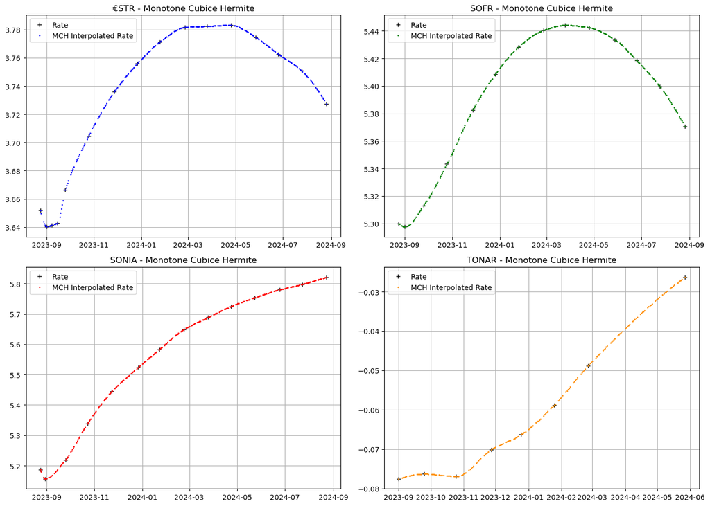

```python
# Plotting the Hermite basis functions
plt.figure(figsize=(14, 10))

# €STR
plt.subplot(2, 2, 1)
plt.plot(ESTR_df['MaturityDate'], ESTR_df['Rate'], '+', label='Rate', color='black',  markersize=6)
plt.plot(ESTR_M['MaturityDate'], ESTR_M['InterpolatedRate'], 'o', label='MCH Interpolated Rate', color='blue', markersize=1)
plt.title("€STR - Monotone Cubice Hermite")
plt.grid(True)
plt.legend()

# SOFR
plt.subplot(2, 2, 2)
plt.plot(SOFR_df['MaturityDate'], SOFR_df['Rate'], '+', label='Rate', color='black',  markersize=6)
plt.plot(SOFR_M['MaturityDate'], SOFR_M['InterpolatedRate'], 'o', label='MCH Interpolated Rate', color='green', markersize=1)
plt.title("SOFR - Monotone Cubice Hermite")
plt.grid(True)
plt.legend()

# SONIA
plt.subplot(2, 2, 3)
plt.plot(SONIA_df['MaturityDate'], SONIA_df['Rate'], '+', label='Rate', color='black',  markersize=6)
plt.plot(SONIA_M['MaturityDate'], SONIA_M['InterpolatedRate'], 'o', label='MCH Interpolated Rate', color='red', markersize=1)
plt.title("SONIA - Monotone Cubice Hermite")
plt.grid(True)
plt.legend()

# TONAR
plt.subplot(2, 2, 4)
plt.plot(TONAR_df['MaturityDate'], TONAR_df['Rate'], '+', label='Rate', color='black',  markersize=6)
plt.plot(TONAR_M['MaturityDate'], TONAR_M['InterpolatedRate'], 'o', label='MCH Interpolated Rate', color='darkorange', markersize=1)
plt.title("TONAR - Monotone Cubice Hermite")
plt.grid(True)
plt.legend()

plt.tight_layout()
plt.show()
```